# index

Alex Medina

2026-10-18

# PART II

## (2.1.1) Scrape a Table

```r
table_url <- "https://en.wikipedia.org/wiki/Community_areas_of_Chicago"

table_page <- read_html(table_url)

# COMMUNITY AREA AND TOTAL POPULATION
wiki_tables <- table_page %>%
  html_elements("table.wikitable") %>%
  html_table()

population_table <- wiki_tables[[2]]

nrow(population_table)
```

```
## [1] 78
```

```r
head(population_table)
```

```
## # A tibble: 6 × 13
##     No. Name           `Total Population` White  `Hispanic/Latino` Black  Asian
##   <int> <chr>          <chr>              <chr>  <chr>             <chr>  <chr>
## 1     1 Rogers Park    54,173             24,150 12,245            11,729 3,389
## 2     2 West Ridge     78,373             30,859 16,129            9,180  17,104
## 3     3 Uptown         56,344             29,284 7,971             10,713 5,831
## 4     4 Lincoln Square 41,651             25,958 7,405             1,732  3,814
## 5     5 North Center   36,014             26,413 4,267             846    2,239
## 6     6 Lake View      102,827            74,953 10,539            4,603  7,480
## # ℹ 6 more variables: `Other/Multiple Races` <chr>, `% White` <dbl>,
## #   `% Hispanic/Latino` <dbl>, `% Black` <dbl>, `% Asian` <dbl>,
## #   `% Other/Multiple Races` <dbl>
```

## (2.1.2)

```r
population_table <- population_table %>%
  clean_names() %>%
  filter(name != "Chicago") %>%
  mutate(total_population = as.numeric(str_remove_all(total_population, ",")))

nrow(population_table)
```

```
## [1] 77
```

```r
head(population_table)
```

```
## # A tibble: 6 × 13
##      no name           total_population white  hispanic_latino black  asian
##   <int> <chr>                     <dbl> <chr>  <chr>           <chr>  <chr>
## 1     1 Rogers Park               54173 24,150 12,245          11,729 3,389
## 2     2 West Ridge                78373 30,859 16,129          9,180  17,104
## 3     3 Uptown                    56344 29,284 7,971           10,713 5,831
## 4     4 Lincoln Square            41651 25,958 7,405           1,732  3,814
## 5     5 North Center              36014 26,413 4,267           846    2,239
## 6     6 Lake View                102827 74,953 10,539          4,603  7,480
## # ℹ 6 more variables: other_multiple_races <chr>, percent_white <dbl>,
## #   percent_hispanic_latino <dbl>, percent_black <dbl>, percent_asian <dbl>,
## #   percent_other_multiple_races <dbl>
```

## (2.1.3)

```r
population_table %>%
  filter(name == "West Town")
```

```
## # A tibble: 1 × 13
##      no name      total_population white  hispanic_latino black asian
##   <int> <chr>                <dbl> <chr>  <chr>           <chr> <chr>
## 1    24 West Town            88164 54,160 17,452          5,355 5,812
## # ℹ 6 more variables: other_multiple_races <chr>, percent_white <dbl>,
## #   percent_hispanic_latino <dbl>, percent_black <dbl>, percent_asian <dbl>,
## #   percent_other_multiple_races <dbl>
```

```r
population_table %>%
  arrange(desc(total_population)) %>%
  head(5)
```

```
## # A tibble: 5 × 13
##      no name            total_population white  hispanic_latino black  asian
##   <int> <chr>                      <dbl> <chr>  <chr>           <chr>  <chr>
## 1     8 Near North Side           107331 69,049 8,884           8,520  15,939
## 2     6 Lake View                 102827 74,953 10,539          4,603  7,480
## 3    25 Austin                     97452 5,452  21,212          67,261 830
## 4    24 West Town                  88164 54,160 17,452          5,355  5,812
## 5     2 West Ridge                 78373 30,859 16,129          9,180  17,104
## # ℹ 6 more variables: other_multiple_races <chr>, percent_white <dbl>,
## #   percent_hispanic_latino <dbl>, percent_black <dbl>, percent_asian <dbl>,
## #   percent_other_multiple_races <dbl>
```

```r
population_table
```

```
## # A tibble: 77 × 13
##       no name            total_population white  hispanic_latino black  asian
##    <int> <chr>                      <dbl> <chr>  <chr>           <chr>  <chr>
##  1     1 Rogers Park                54173 24,150 12,245          11,729 3,389
##  2     2 West Ridge                 78373 30,859 16,129          9,180  17,104
##  3     3 Uptown                     56344 29,284 7,971           10,713 5,831
##  4     4 Lincoln Square             41651 25,958 7,405           1,732  3,814
##  5     5 North Center               36014 26,413 4,267           846    2,239
##  6     6 Lake View                 102827 74,953 10,539          4,603  7,480
##  7     7 Lincoln Park               67987 52,142 5,387           1,680  5,513
##  8     8 Near North Side           107331 69,049 8,884           8,520  15,939
##  9     9 Edison Park                11558 9,181  1,724           70     187
## 10    10 Norwood Park               39840 28,146 7,183           379    2,775
## # ℹ 67 more rows
## # ℹ 6 more variables: other_multiple_races <chr>, percent_white <dbl>,
## #   percent_hispanic_latino <dbl>, percent_black <dbl>, percent_asian <dbl>,
## #   percent_other_multiple_races <dbl>
```

## (2.2.1) Scrape with CSS Selectors

```r
css_url = "https://books.toscrape.com/"
css_page = read_html(css_url)

# Title, Price, Availability
# Title: article.product_pod -> h3 -> a -> title
# Price: article.product_pod -> div.product_price -> p.price_color
# Availability: article.product_pod -> div.product_price -> p.instock.availability

books_table <- css_page %>%
  html_elements("article.product_pod")

title <- books_table %>%
  html_element("h3 a") %>%
  html_attr("title")

price <- books_table %>%
  html_element("p.price_color") %>%
  html_text2()

availability <- books_table %>%
  html_element("p.instock.availability") %>%
  html_text2()

books <- tibble(
  title,
  price,
  availability
)

nrow(books)
```

```
## [1] 20
```

```r
head(books)
```

```
## # A tibble: 6 × 3
##   title                                 price  availability
##   <chr>                                 <chr>  <chr>
## 1 A Light in the Attic                  £51.77 In stock
## 2 Tipping the Velvet                    £53.74 In stock
## 3 Soumission                            £50.10 In stock
## 4 Sharp Objects                         £47.82 In stock
## 5 Sapiens: A Brief History of Humankind £54.23 In stock
## 6 The Requiem Red                       £22.65 In stock
```

## (2.2.2)

```r
books <- books %>%
  mutate(price = as.numeric(str_remove_all(price, "[^0-9.]")))

write_csv(books, "books.csv")

nrow(books)
```

```
## [1] 20
```

```r
head(books)
```

```
## # A tibble: 6 × 3
##   title                                 price availability
##   <chr>                                 <dbl> <chr>
## 1 A Light in the Attic                   51.8 In stock
## 2 Tipping the Velvet                     53.7 In stock
## 3 Soumission                             50.1 In stock
## 4 Sharp Objects                          47.8 In stock
## 5 Sapiens: A Brief History of Humankind  54.2 In stock
## 6 The Requiem Red                        22.6 In stock
```

```r
books
```

```
## # A tibble: 20 × 3
##    title                                                      price availability
##    <chr>                                                      <dbl> <chr>
##  1 A Light in the Attic                                        51.8 In stock
##  2 Tipping the Velvet                                          53.7 In stock
##  3 Soumission                                                  50.1 In stock
##  4 Sharp Objects                                               47.8 In stock
##  5 Sapiens: A Brief History of Humankind                       54.2 In stock
##  6 The Requiem Red                                             22.6 In stock
##  7 The Dirty Little Secrets of Getting Your Dream Job          33.3 In stock
##  8 The Coming Woman: A Novel Based on the Life of the Infamo…  17.9 In stock
##  9 The Boys in the Boat: Nine Americans and Their Epic Quest…  22.6 In stock
## 10 The Black Maria                                             52.2 In stock
## 11 Starving Hearts (Triangular Trade Trilogy, #1)              14.0 In stock
## 12 Shakespeare's Sonnets                                       20.7 In stock
## 13 Set Me Free                                                 17.5 In stock
## 14 Scott Pilgrim's Precious Little Life (Scott Pilgrim #1)     52.3 In stock
## 15 Rip it Up and Start Again                                   35.0 In stock
## 16 Our Band Could Be Your Life: Scenes from the American Ind…  57.2 In stock
## 17 Olio                                                        23.9 In stock
## 18 Mesaerion: The Best Science Fiction Stories 1800-1849       37.6 In stock
## 19 Libertarianism for Beginners                                51.3 In stock
## 20 It's Only the Himalayas                                     45.2 In stock
```

## (2.2.BONUS)

```r
# star-rating (# of stars): article.product_pod -> p.star-rating.(# of stars)
# Grab class "star-rating (# of stars)"
# Remove "star-rating " to leave # of stars

stars <- books_table %>%
  html_element("p.star-rating") %>%
  html_attr("class") %>%
  str_remove("star-rating ")

books <- books %>%
  mutate(rating =
    ifelse(stars == "One", 1,
    ifelse(stars == "Two", 2,
    ifelse(stars == "Three", 3,
    ifelse(stars == "Four", 4, 5)))))

write_csv(books, "books.csv")

nrow(books)
```

```
## [1] 20
```

```r
head(books)
```

```
## # A tibble: 6 × 4
##   title                                 price availability rating
##   <chr>                                 <dbl> <chr>         <dbl>
## 1 A Light in the Attic                   51.8 In stock          3
## 2 Tipping the Velvet                     53.7 In stock          1
## 3 Soumission                             50.1 In stock          1
## 4 Sharp Objects                          47.8 In stock          4
## 5 Sapiens: A Brief History of Humankind  54.2 In stock          5
## 6 The Requiem Red                        22.6 In stock          1
```

```r
books
```

```
## # A tibble: 20 × 4
##    title                                               price availability rating
##    <chr>                                               <dbl> <chr>         <dbl>
##  1 A Light in the Attic                                 51.8 In stock          3
##  2 Tipping the Velvet                                   53.7 In stock          1
##  3 Soumission                                           50.1 In stock          1
##  4 Sharp Objects                                        47.8 In stock          4
##  5 Sapiens: A Brief History of Humankind                54.2 In stock          5
##  6 The Requiem Red                                      22.6 In stock          1
##  7 The Dirty Little Secrets of Getting Your Dream Job   33.3 In stock          4
##  8 The Coming Woman: A Novel Based on the Life of the…  17.9 In stock          3
##  9 The Boys in the Boat: Nine Americans and Their Epi…  22.6 In stock          4
## 10 The Black Maria                                      52.2 In stock          1
## 11 Starving Hearts (Triangular Trade Trilogy, #1)       14.0 In stock          2
## 12 Shakespeare's Sonnets                                20.7 In stock          4
## 13 Set Me Free                                          17.5 In stock          5
## 14 Scott Pilgrim's Precious Little Life (Scott Pilgri…  52.3 In stock          5
## 15 Rip it Up and Start Again                            35.0 In stock          5
## 16 Our Band Could Be Your Life: Scenes from the Ameri…  57.2 In stock          3
## 17 Olio                                                 23.9 In stock          1
## 18 Mesaerion: The Best Science Fiction Stories 1800-1…  37.6 In stock          1
## 19 Libertarianism for Beginners                         51.3 In stock          2
## 20 It's Only the Himalayas                              45.2 In stock          2
```

# PART III

## (3.1)

```r
open_url <- "https://data.cityofchicago.org/resource/v6vf-nfxy.json"

parameters <- list(
  community_area = "24",
  `$where` = "created_date >= '2026-01-01T00:00:00'",
  `$order` = "created_date DESC",
  `$limit` = "1000"
)

data <- GET(open_url, parameters)
```

## (3.2)

```r
west_town <- fromJSON(content(data, "text"), flatten = TRUE)

nrow(west_town)
```

```
## [1] 1000
```

```r
names(west_town)
```

```
##  [1] "sr_number"                   "sr_type"
##  [3] "sr_short_code"               "created_department"
##  [5] "owner_department"            "status"
##  [7] "origin"                      "created_date"
##  [9] "last_modified_date"          "closed_date"
## [11] "street_address"              "city"
## [13] "state"                       "zip_code"
## [15] "street_number"               "street_direction"
## [17] "street_name"                 "street_type"
## [19] "duplicate"                   "legacy_record"
## [21] "created_hour"                "created_day_of_week"
## [23] "created_month"               "community_area"
## [25] "ward"                        "electrical_district"
## [27] "electricity_grid"            "police_sector"
## [29] "police_district"             "police_beat"
## [31] "precinct"                    "x_coordinate"
## [33] "y_coordinate"                "latitude"
## [35] "longitude"                   ":@computed_region_rpca_8um6"
## [37] ":@computed_region_vrxf_vc4k" ":@computed_region_6mkv_f3dw"
## [39] ":@computed_region_bdys_3d7i" ":@computed_region_43wa_7qmu"
## [41] ":@computed_region_du4m_ji7t" "parent_sr_number"
## [43] "location.latitude"           "location.longitude"
## [45] "location.human_address"
```

## (3.3)

```r
top_ten <- west_town %>%
  count(sr_type, sort = TRUE) %>%
  head(10)

top_ten
```

```
##                                    sr_type   n
## 1                 Aircraft Noise Complaint 316
## 2                311 INFORMATION ONLY CALL 269
## 3               Street Light Out Complaint  55
## 4                 Graffiti Removal Request  54
## 5             Rodent Baiting/Rat Complaint  28
## 6               Yard Waste Pick-Up Request  26
## 7                 Garbage Cart Maintenance  20
## 8  Finance Parking Code Enforcement Review  18
## 9              Dead Animal Pick-Up Request  17
## 10            Traffic Signal Out Complaint  12
```

## (3.5) BONUS

### FINISH IF YOU HAVE TIME

```r
top_five <- west_town %>%
  count(sr_type, sort = TRUE) %>%
  head(5) %>%
  pull(sr_type)
```

# PART IV

## (4.1)

- Gross Rent as a Percentage of Household Income, “Total”: **B25070_001E**
- Gross Rent as a Percentage of Household Income, “50.0 percent or more”: **B25070_010E**
- Median Household Income: **B19013_001E**

## (4.2)

```r
ohio <- get_acs(
  geography = "county",
  variables = c(
    Total = "B25070_001E",
    Rent_50 = "B25070_010E",
    median_income = "B19013_001E"
  ),
  state = "OH",
  year = 2024,
  survey = "acs5"
)

head(ohio)
```

```
## # A tibble: 6 × 5
##   GEOID NAME               variable   estimate   moe
##   <chr> <chr>              <chr>         <dbl> <dbl>
## 1 39001 Adams County, Ohio B19013_001    50264  4725
## 2 39001 Adams County, Ohio B25070_001     2954   317
## 3 39001 Adams County, Ohio B25070_010      559   167
## 4 39003 Allen County, Ohio B19013_001    64038  1778
## 5 39003 Allen County, Ohio B25070_001    13343   692
## 6 39003 Allen County, Ohio B25070_010     2537   354
```

## (4.3)

```r
ohio_wider <- ohio %>%
  select(GEOID, NAME, variable, estimate) %>%
  pivot_wider(names_from = variable, values_from = estimate)

ohio_wider <- ohio_wider %>%
  mutate(severe_burden_rate = B25070_010 / B25070_001 * 100) %>%
  arrange(desc(severe_burden_rate))

head(ohio_wider)
```

```
## # A tibble: 6 × 6
##   GEOID NAME                 B19013_001 B25070_001 B25070_010 severe_burden_rate
##   <chr> <chr>                     <dbl>      <dbl>      <dbl>              <dbl>
## 1 39009 Athens County, Ohio       56001       9115       2751               30.2
## 2 39133 Portage County, Ohio      75766      19481       5410               27.8
## 3 39061 Hamilton County, Oh…      72470     144332      35228               24.4
## 4 39145 Scioto County, Ohio       50609       9115       2194               24.1
## 5 39093 Lorain County, Ohio       73347      33139       7971               24.1
## 6 39017 Butler County, Ohio       81590      44147      10603               24.0
```

## (4.BONUS)

```r
ohio_wider <- ohio_wider %>%
  separate(NAME, into = c("county", "state"), ", ")

head(ohio_wider)
```

```
## # A tibble: 6 × 7
##   GEOID county         state B19013_001 B25070_001 B25070_010 severe_burden_rate
##   <chr> <chr>          <chr>      <dbl>      <dbl>      <dbl>              <dbl>
## 1 39009 Athens County  Ohio       56001       9115       2751               30.2
## 2 39133 Portage County Ohio       75766      19481       5410               27.8
## 3 39061 Hamilton Coun… Ohio       72470     144332      35228               24.4
## 4 39145 Scioto County  Ohio       50609       9115       2194               24.1
## 5 39093 Lorain County  Ohio       73347      33139       7971               24.1
## 6 39017 Butler County  Ohio       81590      44147      10603               24.0
```

## (4.4)

```r
ohio_wider %>%
  summarize(
    mean_rate = mean(severe_burden_rate),
    median_rate = median(severe_burden_rate)
  )
```

```
## # A tibble: 1 × 2
##   mean_rate median_rate
##       <dbl>       <dbl>
## 1      18.3        18.7
```

```r
top5 <- ohio_wider %>%
  arrange(desc(severe_burden_rate)) %>%
  head(5)

bottom5 <- ohio_wider %>%
  arrange(severe_burden_rate) %>%
  head(5)
```

## (4.5.1)

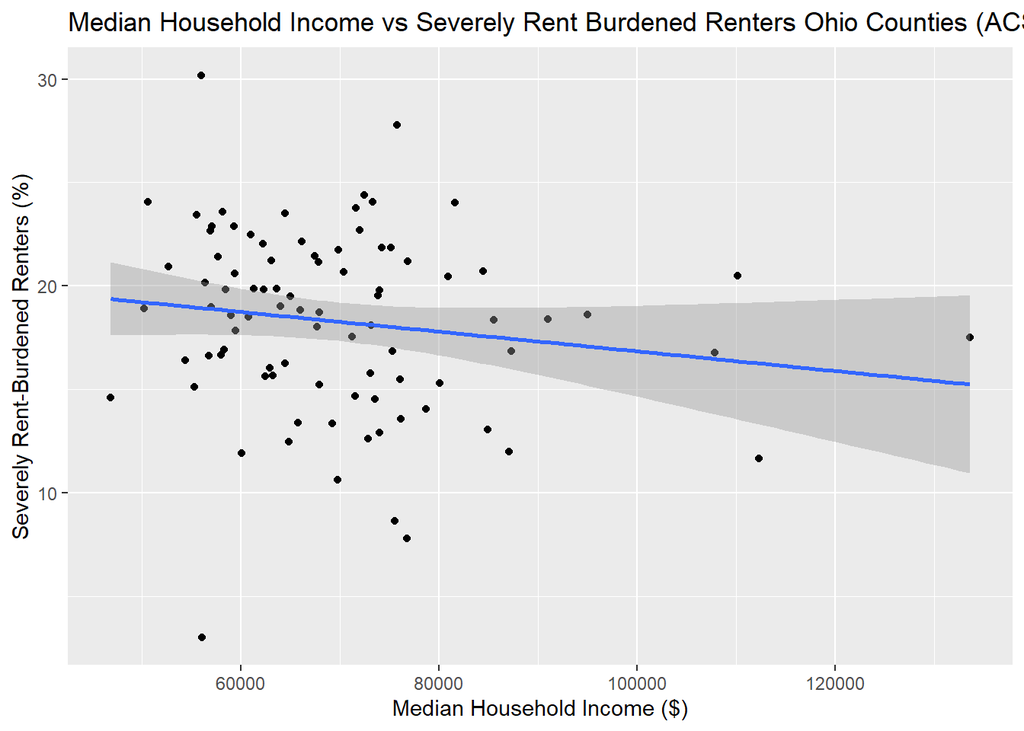

```r
ggplot(ohio_wider, aes(x = B19013_001, y = severe_burden_rate)) +
  geom_point() +
  geom_smooth(method = "lm") +
  labs(
    title = "Median Household Income vs Severely Rent Burdened Renters Ohio Counties (ACS 2024)",
    x = "Median Household Income ($)",
    y = "Severely Rent-Burdened Renters (%)"
  )
```

## (4.5.2)

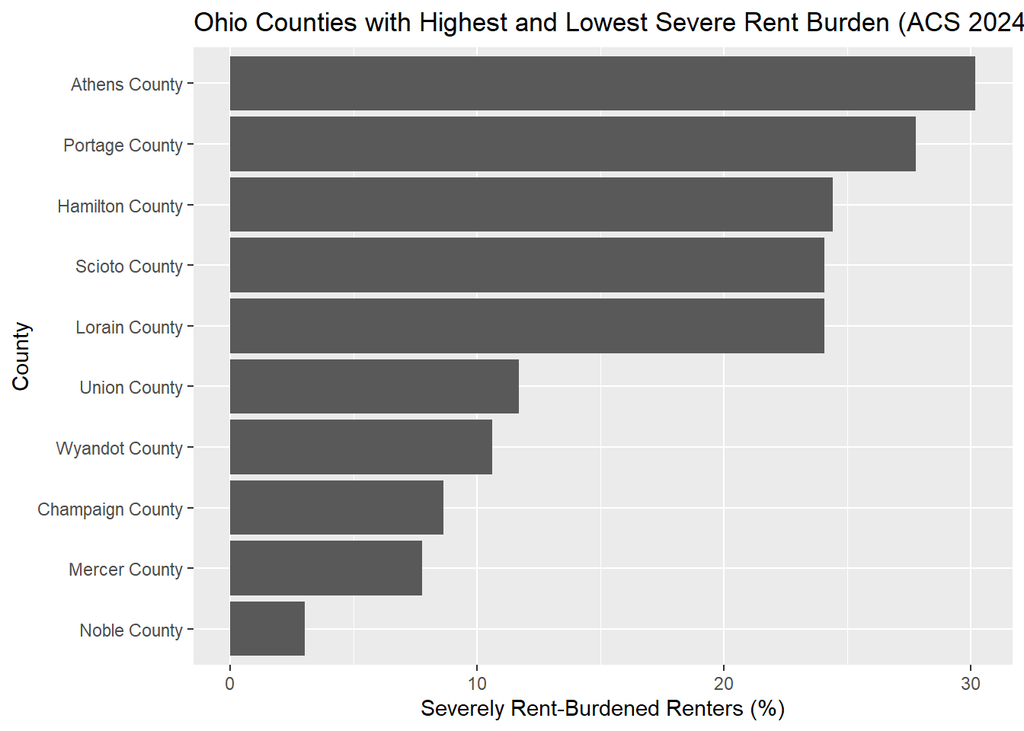

```r
bar <- bind_rows(top5, bottom5)

ggplot(bar, aes(x = reorder(county, severe_burden_rate), y = severe_burden_rate)) +
  geom_col() +
  coord_flip() +
  labs(
    title = "Ohio Counties with Highest and Lowest Severe Rent Burden (ACS 2024)",
    x = "County",
    y = "Severely Rent-Burdened Renters (%)"
  )
```

## (4.6.1)

There isn’t really a strong correlation between income and severe rent burden in Ohio. The line does slope downward, so higher-income counties tend to have a lower severe rent burden. However, the points are very widely scattered so income alone does not likely explain much of the variation. I think rent burdening could apply more to specific neighborhoods or areas rather than household income.

## (4.6.2)

One limitation could probably be how populated the county is. After looking it up, Athens County and Portage County both have universities and college students are more likely have lower income yet pay some kind of rent whether that is through university housing or housing nearby campus. Another limitation could be the amount of places available to rent in different counties compared to just purchasing houses.

# PART V

## (5.1)

Publishing exact addresses and coordinates of 311 requests could most definitely identify the people who made them. They had put a request for information, not to have them exposed. For example, with the aircraft noise complaints, having the address exposed could lead to some kind of retaliation if the complaints lead into some kind of trouble. I would likely use aggregation in order to void the street address and exact coordinates entirely. I would likely just leave it as the neighborhood. I would also suppress the number of requests that is shown if it shows to be too small. I would likely not disclose the number of requests if they are less than ~5.

## (5.2)

Some people are unable to access technology, do not speak the language that 311 may host with, and/or are just unaware of the 311 system. This would lead to many requests not being put in and the only requests that are being noticed are biased toward English Speakers who are able to access technology easier. A city manager would likely see plenty of requests for one area in a primarily English Speaking town and would first go there but would not check other areas that are not the majority. One way to reduce the bias is to add more accessibility / translation options with 311.

## (5.3)

I believe the scraping that I did in Part II was appropriate. The Wikipedia table is public and contains no personal information. Following its reference link, it led me to the “Chicago Metropolitan Agency for Planning”. The website is a government website with the data public as well. I did nothing that would be out of the ordinary for this information to be used nor would it violate any citizen’s privacy. For the CSS portion, “Books to Scrape” is a site built for scraping practice so that also has no ethical concerns either. A situation that would require further review would be with a dataset that holds more private information like addresses, names, or other personal identifiers. This would likely be anything related to court, eviction, and other records.

# AI USAGE

Used it a few times primarily for syntax/grammar errors. I could not figure out what was wrong and realized it was something as simple as “estimmate” and I made sure my wording made sense for explanations considering at the moment of doing the assignment I had put a concerning amount of typos that I would not have caught. I also checked my scatterplot code to make sure it was right because the plot itself did not look quite right and I was concerned. Lastly, I used it to add the {r} since I forgot to add those and was trying to figure out why the code isn’t outputting on the rmd document.